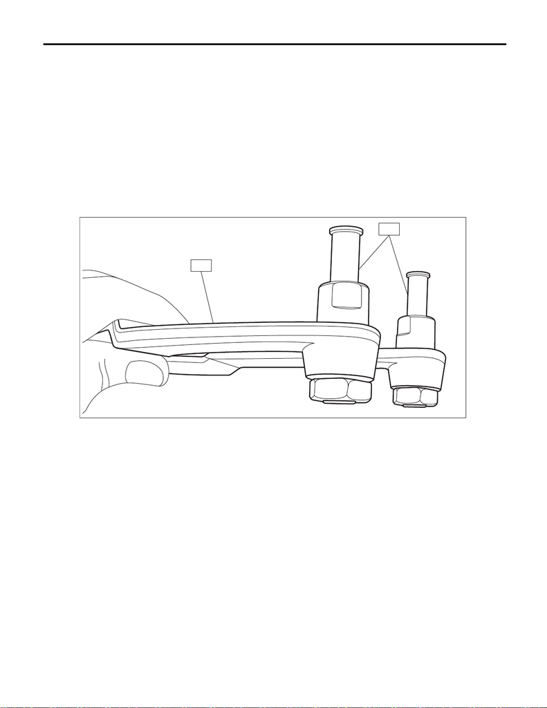

ME(w/o STI)-85

Crank Pulley

MECHANICAL

13.Crank Pulley

A: REMOVAL

NOTE:

When replacing a single part, perform the work with the engine assembly installed to body.

1) Remove the V-belts. <Ref. to ME(w/o STI)-78, V-BELT, REMOVAL, V-belt.>

2) Remove the radiator main fan & fan motor assembly and radiator sub fan & fan motor assembly. <Ref. to

CO(w/o STI)-46, REMOVAL, Radiator Main Fan and Fan Motor.> <Ref. to CO(w/o STI)-49, REMOVAL, Ra-

diator Sub Fan and Fan Motor.>

3) Use the ST to lock the crank pulley, and remove the crank pulley bolt.

NOTE:

To prevent damaging ST1, attach the ST2 onto the ST1 as shown.

ST1 18355AA000 PULLEY WRENCH

ST2 18334AA000 PULLEY WRENCH PIN SET

ME-05125

ST1

ST2

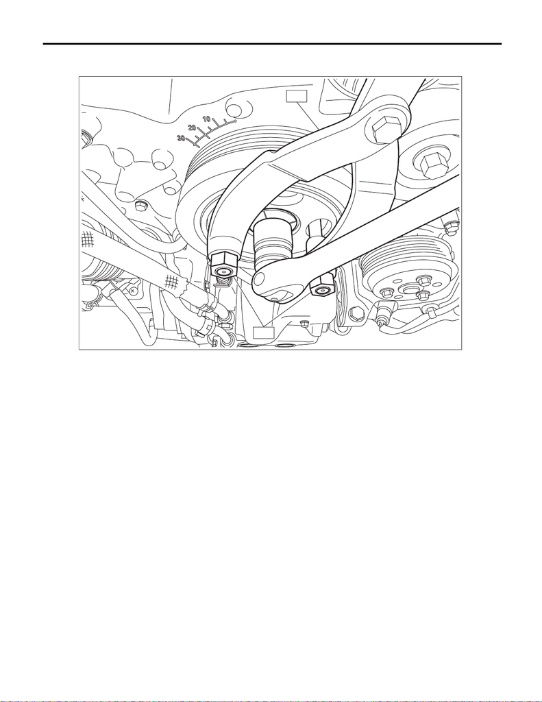

ME(w/o STI)-86

Crank Pulley

MECHANICAL

ST1 18355AA000 PULLEY WRENCH

ST2 18334AA000 PULLEY WRENCH PIN SET

4) Remove the crank pulley.

ME-07922

ST1

ST2

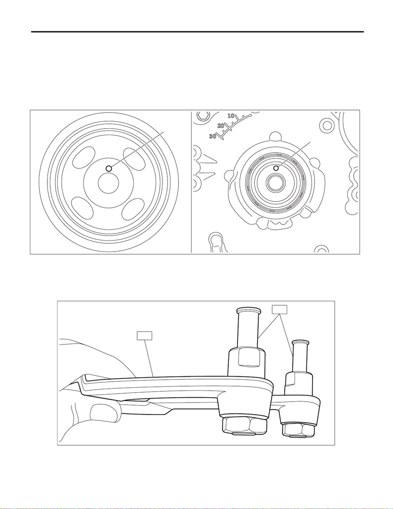

ME(w/o STI)-87

Crank Pulley

MECHANICAL

B: INSTALLATION

1) Clean the crankshaft thread using compressed air.

2) Apply engine oil to the crank pulley bolt seat and thread.

3) Install the crank pulley.

(1) Install the crank pulley to the crank pulley boss.

NOTE:

• Use new O-rings.

• Install the crank pulley by aligning the crank pulley knock hole (A) and crank pulley boss knock pin (B).

(2) Use the ST to lock the crank pulley, and temporarily tighten the crank pulley bolt.

NOTE:

To prevent damaging ST1, attach the ST2 onto the ST1 as shown.

ST1 18355AA000 PULLEY WRENCH

ST2 18334AA000 PULLEY WRENCH PIN SET

ME-06611

(A)

(B)

ME-05125

ST1

ST2

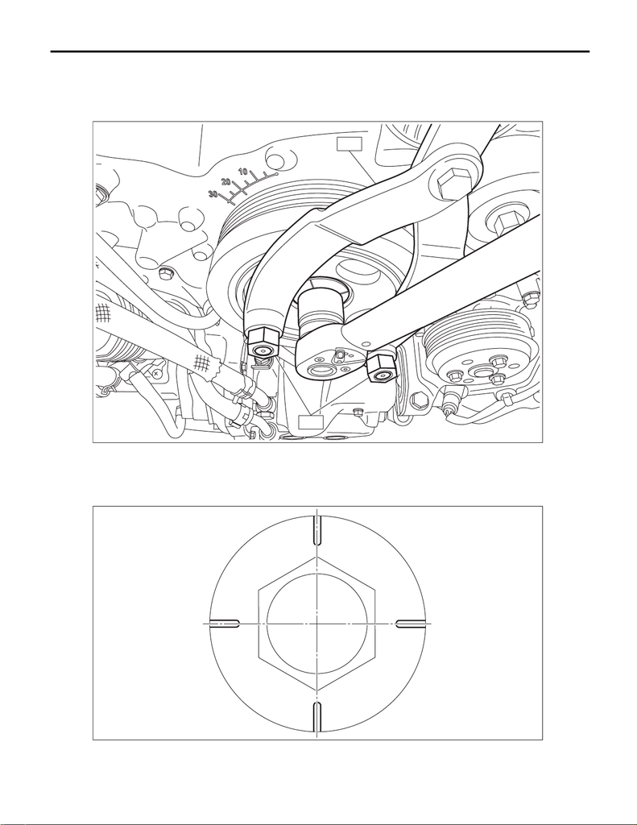

ME(w/o STI)-88

Crank Pulley

MECHANICAL

ST1 18355AA000 PULLEY WRENCH

ST2 18334AA000 PULLEY WRENCH PIN SET

Tightening torque:

20 N·m (2.0 kgf-m, 14.8 ft-lb)

(3) Use the marker as shown in the figure, draw the reference line (A) on the crank pulley bolt according

to the indented line on the crank pulley bolt head, and draw the end line (B) on the crank pulley.

NOTE:

• Four lines are indented by 90° on the crank pulley bolt head.

ME-07923

ST1

ST2

ME-06613

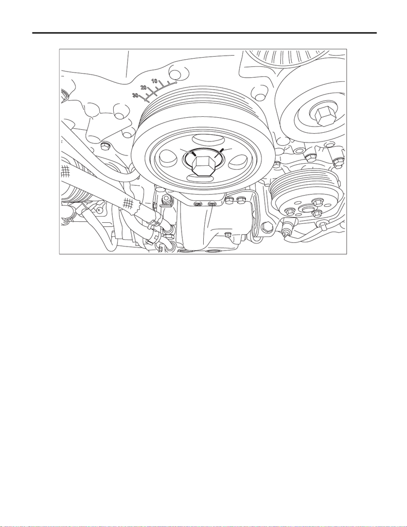

ME(w/o STI)-89

Crank Pulley

MECHANICAL

• Reference line is drawn for better visibility.

ME-07924

(B)

(A)

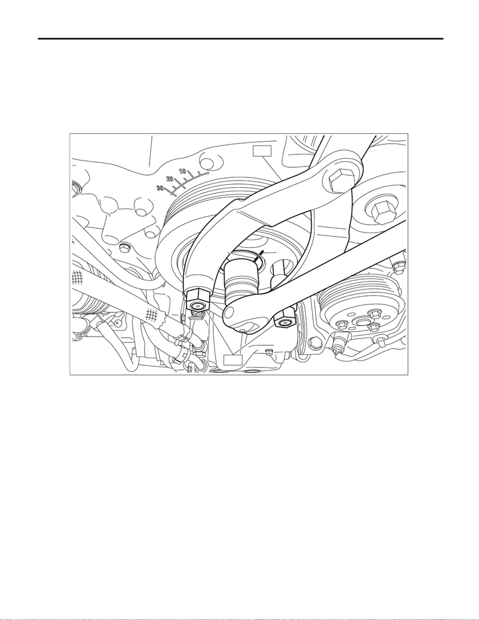

ME(w/o STI)-90

Crank Pulley

MECHANICAL

(4) Use the ST to lock the crank pulley, and tighten the crank pulley bolt to the angle where reference line

(A) and end line (B) are aligned.

NOTE:

It should be approx. 90° when reference line (A) and end line (B) are aligned.

ST1 18355AA000 PULLEY WRENCH

ST2 18334AA000 PULLEY WRENCH PIN SET

Tightening angle:

90°

±

5°

4) Install the radiator main fan & fan motor assembly and radiator sub fan & fan motor assembly. <Ref. to

CO(w/o STI)-46, INSTALLATION, Radiator Main Fan and Fan Motor.> <Ref. to CO(w/o STI)-49, INSTALLA-

TION, Radiator Sub Fan and Fan Motor.>

5) Install the V-belts. <Ref. to ME(w/o STI)-81, V-BELT, INSTALLATION, V-belt.>

ME-07925

ST1

ST2

(A)

(B)

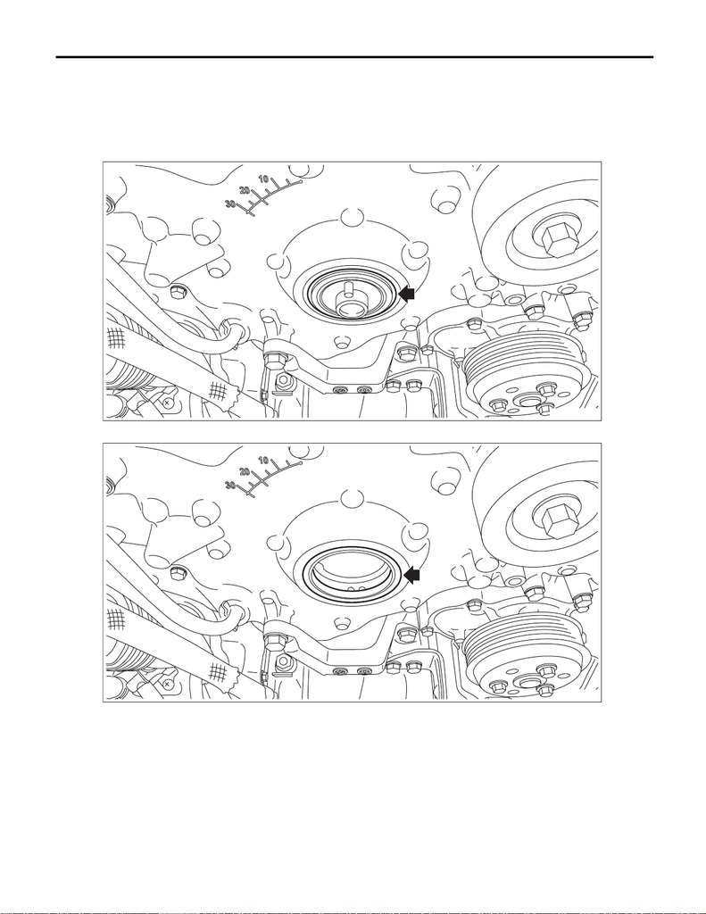

ME(w/o STI)-91

Crank Pulley

MECHANICAL

C: INSPECTION

1) Check that the crank pulley and crank pulley boss have no deformation, cracks or other damages.

2) Inspect for oil leakage from the front oil seal. If there is an oil leak, replace the front oil seal with a new part

according to the following procedures.

(1) Remove the crank pulley. <Ref. to ME(w/o STI)-85, REMOVAL, Crank Pulley.>

(2) Remove the crank pulley boss from the chain cover.

(3) Remove the front oil seal from the chain cover.

ME-07333

ME-07334

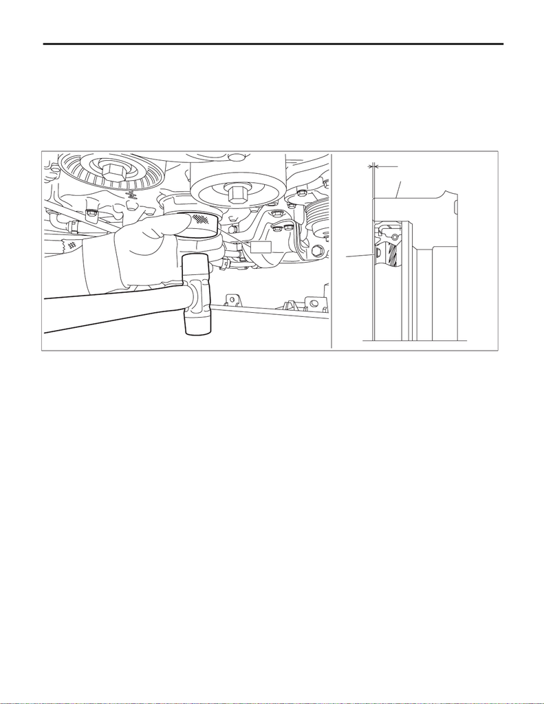

ME(w/o STI)-92

Crank Pulley

MECHANICAL

(4) Apply a light coat of engine oil to the front oil seal inner periphery and outer periphery, and install the

front oil seal to the chain cover using ST.

NOTE:

When tapping the front oil seal in, protect the radiator fin with cardboards etc. so as not to damage the radi-

ator fin by the plastic hammer.

ST 398437700 OIL SEAL INSTALLER

Front oil seal press-fit position:

3) Install in the reverse order of removal after replacement.

tion from chain cover end face)

ME-07926

ST

(B)

(C)

(A)